# Project: No-Show Appointment analysis

- Introduction
- Data Wrangling
- Exploratory Data Analysis
- Conclusions

## Introduction

```
Analysis consists of exploring a dataset containing 100k medial appointments from the
Brazilian health system and is focused on whether or not patients show up for their appointments.
Below are the variables used in dataset and analysis will be done with these data:
```

> **PatientId**: Id of a patient

> **AppointmentID**: Id of each appointment

> **Gender**: Male or Female

> **ScheduledDay**: The day appointment is registered.

> **AppointmentDay**: The day of the actuall appointment

> **Age**: Age of patient

> **Neighbourhood**: Where the appointment hospital located

> **Scholarship**: 0 or 1, indicates if the patient is in Healthcare program

> **Hipertension**: 0 or 1

> **Diabetes**: 1 or 1

> **Alcoholism**: 1 or 1

> **Handcap**: 0 or more

> **SMS_received**: 0 or 1

> **No-show** `No` indicates if the patient showed up to their appointment and `Yes` if they didn't show up

```python
import pandas as pd
import numpy as np
import sys
import matplotlib.pyplot as plt
import seaborn as sns
```

```python
print('Python version :'+ sys.version)
print('Pandas version :'+ pd.__version__)
print('Seaborn version :'+ sns.__version__)
```

```
Python version :3.8.0 (default, Dec 26 2019, 15:35:22)
[Clang 11.0.0 (clang-1100.0.33.16)]
Pandas version :0.25.3
Seaborn version :0.10.0
```

```python
# Loading the dataset and reading the top 5 values
df = pd.read_csv('noshow_appointments.csv')
df.head()
```

|  | PatientId | AppointmentID | Gender | ScheduledDay | AppointmentDay | Age | Neighbourhood | Scholarship | Hipertension | Diabetes | Alcoholism | Handcap | SMS_received | No-show |
| --- | --- | --- | --- | --- | --- | --- | --- | --- | --- | --- | --- | --- | --- | --- |
| 0 | 2.987250e+13 | 5642903 | F | 2016-04-29T18:38:08Z | 2016-04-29T00:00:00Z | 62 | JARDIM DA PENHA | 0 | 1 | 0 | 0 | 0 | 0 | No |
| 1 | 5.589978e+14 | 5642503 | M | 2016-04-29T16:08:27Z | 2016-04-29T00:00:00Z | 56 | JARDIM DA PENHA | 0 | 0 | 0 | 0 | 0 | 0 | No |
| 2 | 4.262962e+12 | 5642549 | F | 2016-04-29T16:19:04Z | 2016-04-29T00:00:00Z | 62 | MATA DA PRAIA | 0 | 0 | 0 | 0 | 0 | 0 | No |
| 3 | 8.679512e+11 | 5642828 | F | 2016-04-29T17:29:31Z | 2016-04-29T00:00:00Z | 8 | PONTAL DE CAMBURI | 0 | 0 | 0 | 0 | 0 | 0 | No |
| 4 | 8.841186e+12 | 5642494 | F | 2016-04-29T16:07:23Z | 2016-04-29T00:00:00Z | 56 | JARDIM DA PENHA | 0 | 1 | 1 | 0 | 0 | 0 | No |

```python
# Finding statistics details of data
df.describe()
```

|  | PatientId | AppointmentID | Age | Scholarship | Hipertension | Diabetes | Alcoholism | Handcap | SMS_received |
| --- | --- | --- | --- | --- | --- | --- | --- | --- | --- |
| count | 1.105270e+05 | 1.105270e+05 | 110527.000000 | 110527.000000 | 110527.000000 | 110527.000000 | 110527.000000 | 110527.000000 | 110527.000000 |
| mean | 1.474963e+14 | 5.675305e+06 | 37.088874 | 0.098266 | 0.197246 | 0.071865 | 0.030400 | 0.022248 | 0.321026 |
| std | 2.560949e+14 | 7.129575e+04 | 23.110205 | 0.297675 | 0.397921 | 0.258265 | 0.171686 | 0.161543 | 0.466873 |
| min | 3.921784e+04 | 5.030230e+06 | -1.000000 | 0.000000 | 0.000000 | 0.000000 | 0.000000 | 0.000000 | 0.000000 |
| 25% | 4.172614e+12 | 5.640286e+06 | 18.000000 | 0.000000 | 0.000000 | 0.000000 | 0.000000 | 0.000000 | 0.000000 |
| 50% | 3.173184e+13 | 5.680573e+06 | 37.000000 | 0.000000 | 0.000000 | 0.000000 | 0.000000 | 0.000000 | 0.000000 |
| 75% | 9.439172e+13 | 5.725524e+06 | 55.000000 | 0.000000 | 0.000000 | 0.000000 | 0.000000 | 0.000000 | 1.000000 |
| max | 9.999816e+14 | 5.790484e+06 | 115.000000 | 1.000000 | 1.000000 | 1.000000 | 1.000000 | 4.000000 | 1.000000 |

```python
# Finding out how many rows and columns are there

df.shape
```

```
(110527, 14)
```

```python
# Exploring the dataset column types
df.info()
```

```
<class 'pandas.core.frame.DataFrame'>
RangeIndex: 110527 entries, 0 to 110526
Data columns (total 14 columns):
PatientId         110527 non-null float64
AppointmentID     110527 non-null int64
Gender            110527 non-null object
ScheduledDay      110527 non-null object
AppointmentDay    110527 non-null object
Age               110527 non-null int64
Neighbourhood     110527 non-null object
Scholarship       110527 non-null int64
Hipertension      110527 non-null int64
Diabetes          110527 non-null int64
Alcoholism        110527 non-null int64
Handcap           110527 non-null int64
SMS_received      110527 non-null int64
No-show           110527 non-null object
dtypes: float64(1), int64(8), object(5)
memory usage: 11.8+ MB
```

### Initial analysis

```
 * There are total 110527 rows and 14 columns
 * No of rows remains same for all columns, so no missing values are seen.
 * ScheduledDay and AppointmentDay is in string format which needs to be changed to date time format
 * PatientID is duplicated, as same person has booked multiple appointments
```

## Data Wrangling

```
In this section, data will be checked for cleanliness, dealing missing values.

Following tasks are performed
    1. Renaming columns to standard format
    2. Identifying the columns that require data type conversion
    3. Dropping the columns having null values
    4. Checking for duplicates
    5. Checking whether data needs to be categorized for detailed analysis
```

```python
# Renaming the column names to standard format
df.rename(columns = {'PatientId':'patient_id','AppointmentID':'appointment_id','ScheduledDay':'scheduled_day','AppointmentDay':'appointment_day',
                    'SMS_received':'sms_received','No-show':'no_show'},inplace = True)
df.head(1)
```

|  | patient_id | appointment_id | Gender | scheduled_day | appointment_day | Age | Neighbourhood | Scholarship | Hipertension | Diabetes | Alcoholism | Handcap | sms_received | no_show |
| --- | --- | --- | --- | --- | --- | --- | --- | --- | --- | --- | --- | --- | --- | --- |
| 0 | 2.987250e+13 | 5642903 | F | 2016-04-29T18:38:08Z | 2016-04-29T00:00:00Z | 62 | JARDIM DA PENHA | 0 | 1 | 0 | 0 | 0 | 0 | No |

```python
# Converting column names to lower case
columns =['patient_id','appointment_id','Gender','scheduled_day','appointment_day','Age','Neighbourhood','Scholarship','Hipertension','Diabetes','Alcoholism','Handcap','sms_received','no_show']

df.rename(columns = lambda x: x.lower(),inplace=True)
df.head(1)
```

|  | patient_id | appointment_id | gender | scheduled_day | appointment_day | age | neighbourhood | scholarship | hipertension | diabetes | alcoholism | handcap | sms_received | no_show |
| --- | --- | --- | --- | --- | --- | --- | --- | --- | --- | --- | --- | --- | --- | --- |
| 0 | 2.987250e+13 | 5642903 | F | 2016-04-29T18:38:08Z | 2016-04-29T00:00:00Z | 62 | JARDIM DA PENHA | 0 | 1 | 0 | 0 | 0 | 0 | No |

#### patient_id column has float as datatype which needs to converted to string.

#### scheduled_day and appointment_day columns are having String format which needs to converted to dateTime format.

```python
# Converting patient_id data type
df['patient_id'] = df.patient_id.apply(lambda p : str(int(p)))

df.head(1)
```

|  | patient_id | appointment_id | gender | scheduled_day | appointment_day | age | neighbourhood | scholarship | hipertension | diabetes | alcoholism | handcap | sms_received | no_show |
| --- | --- | --- | --- | --- | --- | --- | --- | --- | --- | --- | --- | --- | --- | --- |
| 0 | 29872499824296 | 5642903 | F | 2016-04-29T18:38:08Z | 2016-04-29T00:00:00Z | 62 | JARDIM DA PENHA | 0 | 1 | 0 | 0 | 0 | 0 | No |

```python
# No-show is mentioned as String datatype. Will convert the values to {'Yes': 0 ,'No':1}.
# As No-show : Yes means patient didnt turn up for appointment and
# No-show : No means patient turned up for appointment

print(df.no_show.value_counts())

df['no_show'] = df['no_show'].replace({'Yes':0,'No':1})

print(df.no_show.value_counts())
```

```
No     88208
Yes    22319
Name: no_show, dtype: int64
1    88208
0    22319
Name: no_show, dtype: int64
```

```python
df.head()
```

|  | patient_id | appointment_id | gender | scheduled_day | appointment_day | age | neighbourhood | scholarship | hipertension | diabetes | alcoholism | handcap | sms_received | no_show |
| --- | --- | --- | --- | --- | --- | --- | --- | --- | --- | --- | --- | --- | --- | --- |
| 0 | 29872499824296 | 5642903 | F | 2016-04-29T18:38:08Z | 2016-04-29T00:00:00Z | 62 | JARDIM DA PENHA | 0 | 1 | 0 | 0 | 0 | 0 | 1 |
| 1 | 558997776694438 | 5642503 | M | 2016-04-29T16:08:27Z | 2016-04-29T00:00:00Z | 56 | JARDIM DA PENHA | 0 | 0 | 0 | 0 | 0 | 0 | 1 |
| 2 | 4262962299951 | 5642549 | F | 2016-04-29T16:19:04Z | 2016-04-29T00:00:00Z | 62 | MATA DA PRAIA | 0 | 0 | 0 | 0 | 0 | 0 | 1 |
| 3 | 867951213174 | 5642828 | F | 2016-04-29T17:29:31Z | 2016-04-29T00:00:00Z | 8 | PONTAL DE CAMBURI | 0 | 0 | 0 | 0 | 0 | 0 | 1 |
| 4 | 8841186448183 | 5642494 | F | 2016-04-29T16:07:23Z | 2016-04-29T00:00:00Z | 56 | JARDIM DA PENHA | 0 | 1 | 1 | 0 | 0 | 0 | 1 |

```python
#ScheduledDay and AppointmentDay are in String format. It is better to be in DateTime format

df.scheduled_day = pd.to_datetime(df.scheduled_day)
df.appointment_day = pd.to_datetime(df.appointment_day)

df.head()
```

|  | patient_id | appointment_id | gender | scheduled_day | appointment_day | age | neighbourhood | scholarship | hipertension | diabetes | alcoholism | handcap | sms_received | no_show |
| --- | --- | --- | --- | --- | --- | --- | --- | --- | --- | --- | --- | --- | --- | --- |
| 0 | 29872499824296 | 5642903 | F | 2016-04-29 18:38:08+00:00 | 2016-04-29 00:00:00+00:00 | 62 | JARDIM DA PENHA | 0 | 1 | 0 | 0 | 0 | 0 | 1 |
| 1 | 558997776694438 | 5642503 | M | 2016-04-29 16:08:27+00:00 | 2016-04-29 00:00:00+00:00 | 56 | JARDIM DA PENHA | 0 | 0 | 0 | 0 | 0 | 0 | 1 |
| 2 | 4262962299951 | 5642549 | F | 2016-04-29 16:19:04+00:00 | 2016-04-29 00:00:00+00:00 | 62 | MATA DA PRAIA | 0 | 0 | 0 | 0 | 0 | 0 | 1 |
| 3 | 867951213174 | 5642828 | F | 2016-04-29 17:29:31+00:00 | 2016-04-29 00:00:00+00:00 | 8 | PONTAL DE CAMBURI | 0 | 0 | 0 | 0 | 0 | 0 | 1 |
| 4 | 8841186448183 | 5642494 | F | 2016-04-29 16:07:23+00:00 | 2016-04-29 00:00:00+00:00 | 56 | JARDIM DA PENHA | 0 | 1 | 1 | 0 | 0 | 0 | 1 |

```python
# Figuring out which day of the week appointment falls in. In order to figure that which day has more appointments

df['appointment_week_day'] = df['appointment_day'].dt.day_name()
df.head()
```

|  | patient_id | appointment_id | gender | scheduled_day | appointment_day | age | neighbourhood | scholarship | hipertension | diabetes | alcoholism | handcap | sms_received | no_show | appointment_week_day |
| --- | --- | --- | --- | --- | --- | --- | --- | --- | --- | --- | --- | --- | --- | --- | --- |
| 0 | 29872499824296 | 5642903 | F | 2016-04-29 18:38:08+00:00 | 2016-04-29 00:00:00+00:00 | 62 | JARDIM DA PENHA | 0 | 1 | 0 | 0 | 0 | 0 | 1 | Friday |
| 1 | 558997776694438 | 5642503 | M | 2016-04-29 16:08:27+00:00 | 2016-04-29 00:00:00+00:00 | 56 | JARDIM DA PENHA | 0 | 0 | 0 | 0 | 0 | 0 | 1 | Friday |
| 2 | 4262962299951 | 5642549 | F | 2016-04-29 16:19:04+00:00 | 2016-04-29 00:00:00+00:00 | 62 | MATA DA PRAIA | 0 | 0 | 0 | 0 | 0 | 0 | 1 | Friday |
| 3 | 867951213174 | 5642828 | F | 2016-04-29 17:29:31+00:00 | 2016-04-29 00:00:00+00:00 | 8 | PONTAL DE CAMBURI | 0 | 0 | 0 | 0 | 0 | 0 | 1 | Friday |
| 4 | 8841186448183 | 5642494 | F | 2016-04-29 16:07:23+00:00 | 2016-04-29 00:00:00+00:00 | 56 | JARDIM DA PENHA | 0 | 1 | 1 | 0 | 0 | 0 | 1 | Friday |

```python
# Finding out gap between appointment day and scheduled day and taking absolute value to remove negative numbers
df['wait_days'] = ( df.scheduled_day - df.appointment_day).abs().dt.days

df.head()
```

|  | patient_id | appointment_id | gender | scheduled_day | appointment_day | age | neighbourhood | scholarship | hipertension | diabetes | alcoholism | handcap | sms_received | no_show | appointment_week_day | wait_days |
| --- | --- | --- | --- | --- | --- | --- | --- | --- | --- | --- | --- | --- | --- | --- | --- | --- |
| 0 | 29872499824296 | 5642903 | F | 2016-04-29 18:38:08+00:00 | 2016-04-29 00:00:00+00:00 | 62 | JARDIM DA PENHA | 0 | 1 | 0 | 0 | 0 | 0 | 1 | Friday | 0 |
| 1 | 558997776694438 | 5642503 | M | 2016-04-29 16:08:27+00:00 | 2016-04-29 00:00:00+00:00 | 56 | JARDIM DA PENHA | 0 | 0 | 0 | 0 | 0 | 0 | 1 | Friday | 0 |
| 2 | 4262962299951 | 5642549 | F | 2016-04-29 16:19:04+00:00 | 2016-04-29 00:00:00+00:00 | 62 | MATA DA PRAIA | 0 | 0 | 0 | 0 | 0 | 0 | 1 | Friday | 0 |
| 3 | 867951213174 | 5642828 | F | 2016-04-29 17:29:31+00:00 | 2016-04-29 00:00:00+00:00 | 8 | PONTAL DE CAMBURI | 0 | 0 | 0 | 0 | 0 | 0 | 1 | Friday | 0 |
| 4 | 8841186448183 | 5642494 | F | 2016-04-29 16:07:23+00:00 | 2016-04-29 00:00:00+00:00 | 56 | JARDIM DA PENHA | 0 | 1 | 1 | 0 | 0 | 0 | 1 | Friday | 0 |

```python
# Finding out the wait_days statistical data.
df.wait_days.describe()
```

```
count    110527.000000
mean          9.532829
std          15.027683
min           0.000000
25%           0.000000
50%           3.000000
75%          14.000000
max         178.000000
Name: wait_days, dtype: float64
```

```python
# Lets figure out duplicated values in dataset

print(sum(df.patient_id.duplicated()))
print(sum(df.appointment_id.duplicated()))
```

```
48228
0
```

#### Duplicated patient_id is an indication that same patients have made multiple appointments

#### As appointment_id is a unique value and doesnt have any other dependencies this column can be dropped

```python
#Dropping column appointment_id

df.drop(['appointment_id'],axis =1, inplace = True)
df.head(1)
```

|  | patient_id | gender | scheduled_day | appointment_day | age | neighbourhood | scholarship | hipertension | diabetes | alcoholism | handcap | sms_received | no_show | appointment_week_day | wait_days |
| --- | --- | --- | --- | --- | --- | --- | --- | --- | --- | --- | --- | --- | --- | --- | --- |
| 0 | 29872499824296 | F | 2016-04-29 18:38:08+00:00 | 2016-04-29 00:00:00+00:00 | 62 | JARDIM DA PENHA | 0 | 1 | 0 | 0 | 0 | 0 | 1 | Friday | 0 |

```python
# Finding the type of values for each of the below columns

columns = ['gender','scholarship','hipertension','diabetes','alcoholism','handcap',
           'sms_received','no_show','appointment_week_day','wait_days']
for c in columns:
    print(df[c].value_counts())
```

```
F    71840
M    38687
Name: gender, dtype: int64
0    99666
1    10861
Name: scholarship, dtype: int64
0    88726
1    21801
Name: hipertension, dtype: int64
0    102584
1      7943
Name: diabetes, dtype: int64
0    107167
1      3360
Name: alcoholism, dtype: int64
0    108286
1      2042
2       183
3        13
4         3
Name: handcap, dtype: int64
0    75045
1    35482
Name: sms_received, dtype: int64
1    88208
0    22319
Name: no_show, dtype: int64
Wednesday    25867
Tuesday      25640
Monday       22715
Friday       19019
Thursday     17247
Saturday        39
Name: appointment_week_day, dtype: int64
0      43776
1       6729
3       5290
6       4907
5       4037
       ...
122        1
124        1
138        1
145        1
131        1
Name: wait_days, Length: 128, dtype: int64
```

#### From the above, handicap column has some random values other than 0 or 1.

#### As per dataset mentioned in Kaggle, handicap can have values True or False (1 or 0).

#### Will be updating values > 1 to 1 itself as indication of handicap is True

```python
#Updating values in handicap column

df['handcap'] = df['handcap'].apply(lambda x : 1 if x > 1 else x)
df.handcap.value_counts()
```

```
0    108286
1      2241
Name: handcap, dtype: int64
```

```python
#Obtaining statistical data for the columns
df.describe()
```

|  | age | scholarship | hipertension | diabetes | alcoholism | handcap | sms_received | no_show | wait_days |
| --- | --- | --- | --- | --- | --- | --- | --- | --- | --- |
| count | 110527.000000 | 110527.000000 | 110527.000000 | 110527.000000 | 110527.000000 | 110527.000000 | 110527.000000 | 110527.000000 | 110527.000000 |
| mean | 37.088874 | 0.098266 | 0.197246 | 0.071865 | 0.030400 | 0.020276 | 0.321026 | 0.798067 | 9.532829 |
| std | 23.110205 | 0.297675 | 0.397921 | 0.258265 | 0.171686 | 0.140942 | 0.466873 | 0.401444 | 15.027683 |
| min | -1.000000 | 0.000000 | 0.000000 | 0.000000 | 0.000000 | 0.000000 | 0.000000 | 0.000000 | 0.000000 |
| 25% | 18.000000 | 0.000000 | 0.000000 | 0.000000 | 0.000000 | 0.000000 | 0.000000 | 1.000000 | 0.000000 |
| 50% | 37.000000 | 0.000000 | 0.000000 | 0.000000 | 0.000000 | 0.000000 | 0.000000 | 1.000000 | 3.000000 |
| 75% | 55.000000 | 0.000000 | 0.000000 | 0.000000 | 0.000000 | 0.000000 | 1.000000 | 1.000000 | 14.000000 |
| max | 115.000000 | 1.000000 | 1.000000 | 1.000000 | 1.000000 | 1.000000 | 1.000000 | 1.000000 | 178.000000 |

#### Here age has a minimum of -1. Since -1 is not a valid one, we will figure how many such values are there

```python
# Figuring how many negative age values are present
df.age.value_counts()
```

```
 0      3539
 1      2273
 52     1746
 49     1652
 53     1651
        ...
 115       5
 100       4
 102       2
 99        1
-1         1
Name: age, Length: 104, dtype: int64
```

#### Since there is only one value, will drop the row with the value of 1.

```python
# Dropping the row with negative age value

df.drop(df[df['age']<0].index,inplace=True)

print(sorted(df['age'].unique()))
```

[output not shown]

## Exploratory Data Analysis

```
Now data is trimmed and cleaned your data, you're ready to move on to exploration

The questions I would be exploring here :
```

##### 1. Which is most important factor influencing patient showing up for appointment?

##### 2. How does waiting time for appointment affects showing up for appointment?

##### 3. Does locality has any influence on appointment show up?

##### 4. Does Health Program enrollment has impact on patient show up?

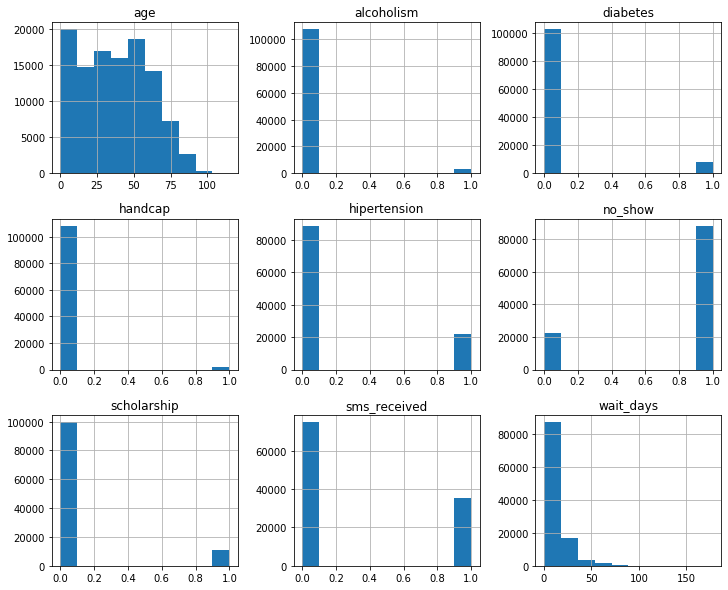

```python
# plot basic histogram charts

_ = df.hist(figsize = (12,10))
```

#### From above histogram,

##### * Patients are mostly < 60 yrs of age

##### * Higher percentage doesnt have any medicals conditions like alcoholism / diabetes / hipertension

##### * Larger no of patients didnt receive SMS

##### * Patients not belonging to health program is very high

```python
# Method to plot using seaborn plot for no_show rate
# dataset : current dataset
# feature : feature against which no_show_rate is plotted
# xlabel : label name of the feature
# fsize : font size required for plotting
# additional_plot_status : Adding extra parameters to plot for better visualization

def feature_no_show_plot(dataset,feature,xlabel,fsize, additional_plot_status):
    no_show = sns.countplot(x= feature,hue='no_show',data=dataset)
    no_show.set_xlabel(xlabel,fontsize = fsize)
    no_show.set_ylabel("No of patients",fontsize = fsize)

    if additional_plot_status == True:
        no_show.tick_params(labelsize = 20)
        no_show.set_xticklabels(no_show.get_xticklabels(),rotation=90)
        plt.legend(fontsize=20)

    plt.title('Appointment show up based on '+xlabel, fontsize = fsize)
    plt.show()
```

```python
# Method to plot percentage distribution of various datapoints using pie chart

def feature_percentage_distribution_no_show(percent,values,colors,explode,feature, fsize):
    plt.pie(percent, colors=colors, labels=values, explode=explode ,startangle=90, autopct='%1.1f%%')
    plt.title("Appointment show up by "+feature , fontsize=12)
    plt.show()
```

##### Analyzing and visualizing no-show based on below parameters

.

- Age

.

- Gender

.

- Neighbourhood

.

- Medical Condition

.

- Health Program

.

- Appointment Week Days

.

- SMS Received

.

- WaitDays

### Age

```python
# Getting statistical data for Age

df.describe().age
```

```
count    110526.000000
mean         37.089219
std          23.110026
min           0.000000
25%          18.000000
50%          37.000000
75%          55.000000
max         115.000000
Name: age, dtype: float64
```

```python
# categorizing age into different groups :- <18, 18-36, 37-54, 55-74, >=75

bins = [0,18,37,55,75,115]
bin_name = ['<18','18-36','37-54','55-74','>=75']

df['age_group'] = pd.cut(df['age'],bins,labels = bin_name,include_lowest = True)
df.head()
```

|  | patient_id | gender | scheduled_day | appointment_day | age | neighbourhood | scholarship | hipertension | diabetes | alcoholism | handcap | sms_received | no_show | appointment_week_day | wait_days | age_group |
| --- | --- | --- | --- | --- | --- | --- | --- | --- | --- | --- | --- | --- | --- | --- | --- | --- |
| 0 | 29872499824296 | F | 2016-04-29 18:38:08+00:00 | 2016-04-29 00:00:00+00:00 | 62 | JARDIM DA PENHA | 0 | 1 | 0 | 0 | 0 | 0 | 1 | Friday | 0 | 55-74 |
| 1 | 558997776694438 | M | 2016-04-29 16:08:27+00:00 | 2016-04-29 00:00:00+00:00 | 56 | JARDIM DA PENHA | 0 | 0 | 0 | 0 | 0 | 0 | 1 | Friday | 0 | 55-74 |
| 2 | 4262962299951 | F | 2016-04-29 16:19:04+00:00 | 2016-04-29 00:00:00+00:00 | 62 | MATA DA PRAIA | 0 | 0 | 0 | 0 | 0 | 0 | 1 | Friday | 0 | 55-74 |
| 3 | 867951213174 | F | 2016-04-29 17:29:31+00:00 | 2016-04-29 00:00:00+00:00 | 8 | PONTAL DE CAMBURI | 0 | 0 | 0 | 0 | 0 | 0 | 1 | Friday | 0 | <18 |
| 4 | 8841186448183 | F | 2016-04-29 16:07:23+00:00 | 2016-04-29 00:00:00+00:00 | 56 | JARDIM DA PENHA | 0 | 1 | 1 | 0 | 0 | 0 | 1 | Friday | 0 | 55-74 |

```python
# Lets now find out how many are there in each category

df_ages = pd.DataFrame(df['age_group'].value_counts())
df_ages
```

|  | age_group |
| --- | --- |
| <18 | 28866 |
| 18-36 | 27250 |
| 37-54 | 26906 |
| 55-74 | 22112 |
| >=75 | 5392 |

```python
# Grouping the data so that we will get in each category show and no show counts

df_age_group = df.groupby(['age_group','no_show']).count()['age']
df_age_group
```

```
age_group  no_show
<18        0           6347
           1          22519
18-36      0           6414
           1          20836
37-54      0           5255
           1          21651
55-74      0           3433
           1          18679
>=75       0            870
           1           4522
Name: age, dtype: int64
```

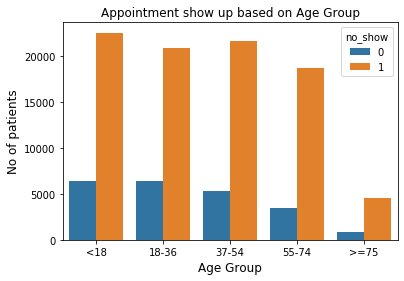

```python
# Using seaborn to plot a countplot for age_group vs no of patients no show

feature_no_show_plot(df,"age_group","Age Group",12,False)
```

```python
# Calculating percentage of patient turn up for each group

below_eighteen = df_age_group['<18',1]/ df.age_group.value_counts()['<18'] * 100
eighteen_thirtysix = df_age_group['18-36',1]/df.age_group.value_counts()['18-36'] * 100
thirtyseven_fiftyfour= df_age_group['37-54',1]/df.age_group.value_counts()['37-54'] * 100
fiftyfive_seventyfour = df_age_group['55-74',1]/df.age_group.value_counts()['55-74'] * 100
morethan_seventyfive = df_age_group['>=75',1]/df.age_group.value_counts()['>=75'] * 100
```

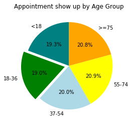

```python
# Let's use pie chart to see the distribution

percent = [below_eighteen,eighteen_thirtysix,thirtyseven_fiftyfour,fiftyfive_seventyfour,morethan_seventyfive]
values = ['<18','18-36','37-54','55-74','>=75']
colors = ['teal','green','lightblue','yellow','orange']
explode = [0,0.1,0,0,0]

feature_percentage_distribution_no_show(percent,values,colors,explode,"Age Group", 12)
```

#### Patients in the age group above 37 yrs have a higher show up for appointments than kids(<18) and adults (18-36)

### Gender

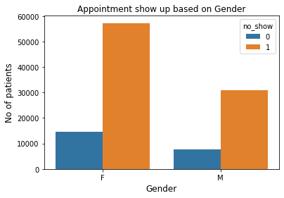

```python
# Using seaborn, bar plot for no-show based on gender

feature_no_show_plot(df,"gender","Gender",12,False)
```

```
Percentage of women who turn up for appointment : 64.9
Percentage of men who turn up for appointment : 35.1
```

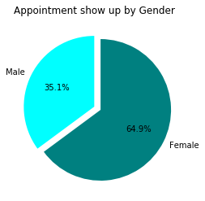

```python
## Find no of males who has not shown up for appointments
male_count_show = df.query('gender == "M" and no_show == 1').no_show.count()

# Find no of femails who has not shown up for appointments
female_count_show = df.query('gender == "F" and no_show == 1').no_show.count()
total_show = df.query('no_show == 1').no_show.count()

female_show_percentage = female_count_show/total_show *100
male_show_percentage = male_count_show / total_show * 100

print("Percentage of women who turn up for appointment :",round(female_show_percentage,2))
print("Percentage of men who turn up for appointment :", round(male_show_percentage,2))

percent = [male_show_percentage,female_show_percentage]
values = ['Male','Female']

explode = [0,0.1]
colors = ['cyan','teal']

feature_percentage_distribution_no_show(percent,values,colors,explode,"Gender", 12)
```

#### From above graph, women turning up for appointments are much greater than men turning up.

### Neighbourhood

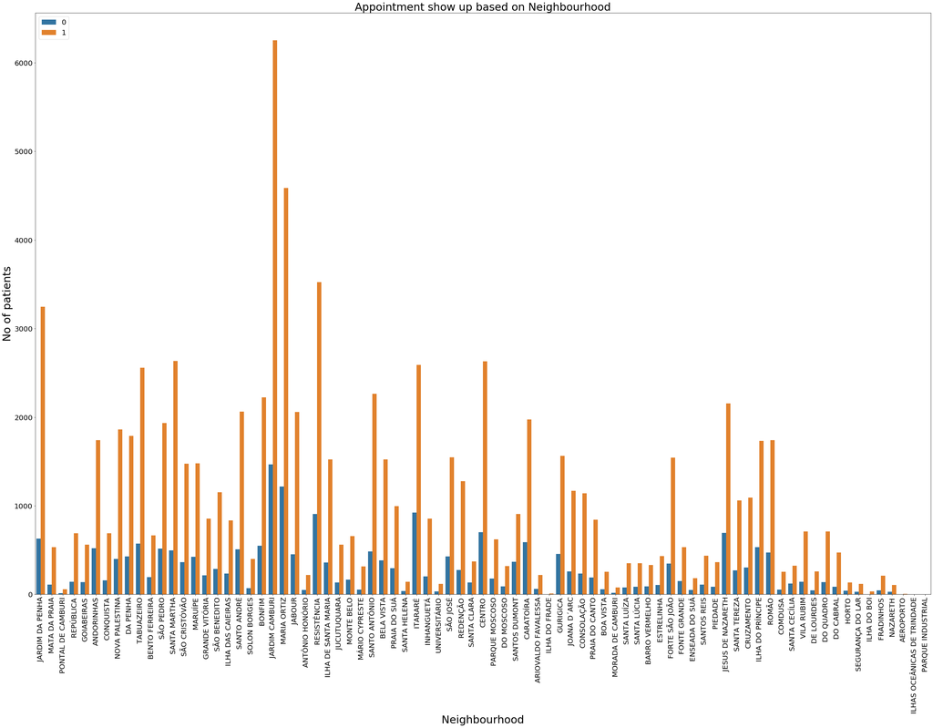

```python
# Using seaborn, bar plot for no-show based on neighbourhood
fig = plt.figure(figsize=(45,30))

feature_no_show_plot(df,"neighbourhood","Neighbourhood",30,True)
```

```python
# Finding the show count in descending order
df_neighbourhood = df.groupby('neighbourhood').sum()['no_show'].sort_values(ascending=False)
print(df_neighbourhood)
```

```
neighbourhood
JARDIM CAMBURI                 6252
MARIA ORTIZ                    4586
RESISTÊNCIA                    3525
JARDIM DA PENHA                3246
SANTA MARTHA                   2635
                               ...
ILHA DO BOI                      32
ILHA DO FRADE                     8
AEROPORTO                         7
PARQUE INDUSTRIAL                 1
ILHAS OCEÂNICAS DE TRINDADE       0
Name: no_show, Length: 81, dtype: int64
```

```python
neighbourhood_show = df.query('neighbourhood =="JARDIM CAMBURI" and no_show == 1').no_show.count()
total_show = df.query('no_show == 1').no_show.count()

neighbourhood_show_percentage = neighbourhood_show / total_show * 100

print("Percentage of turn up for appointment in neighbourhood :",round(neighbourhood_show_percentage,2))
```

```
Percentage of turn up for appointment in neighbourhood : 7.09
```

#### From above, its clear that Jardim Camburi has the highest number of appointments and highest number of show up also.

### Medical Condition

#### 1.1 Diabetes

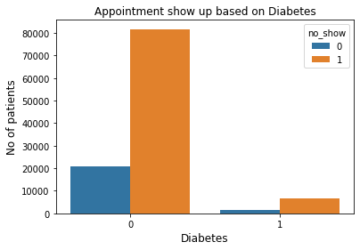

```python
# Plotting diabetes vs No show
feature_no_show_plot(df,"diabetes","Diabetes",12,False)
```

```python
diabetes_show_count = df.query('diabetes == 1 and no_show== 1').no_show.count()
total_show = df.query('no_show == 1').no_show.count()
diabetes_show_percentage = diabetes_no_show_count/total_show *100
```

#### 1.2 Hipertension

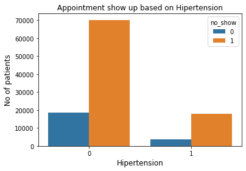

```python
# Plotting hipertension vs No show
feature_no_show_plot(df,"hipertension","Hipertension",12,False)
```

```python
hipertension_show_count = df.query('hipertension == 1 and no_show == 1').no_show.count()
total_show = df.query('no_show == 1').no_show.count()

hipertension_show_percentage = hipertension_no_show_count / total_show * 100
```

#### 1.3 Alcoholism

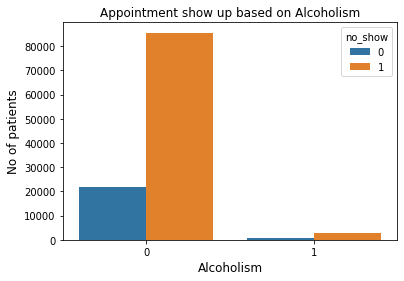

```python
# Plotting alcoholism vs No show
feature_no_show_plot(df,"alcoholism","Alcoholism",12,False)
```

```python
alcoholism_count = df.query('alcoholism == 1 and no_show == 1').no_show.count()
total_show = df.query('no_show == 1').no_show.count()
alcoholism_show_percentage = alcoholism_no_show_count / total_show * 100
```

#### 1.4 Handcap

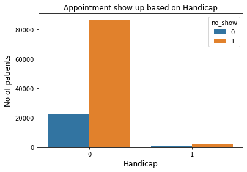

```python
# Plotting handcap vs No show
feature_no_show_plot(df,"handcap","Handicap",12,False)
```

```python
handcap_show_count = df.query('handcap == 1 and no_show == 1').no_show.count()
total_show = df.query('no_show == 1').no_show.count()

handcap_show_percentage = handcap_no_show_count  / total_show * 100
```

```python
print("Percentage of diabetics patients who turn for appointment: ",round(diabetes_show_percentage,2))
print("Percentage of hipertension patients who turn for appointments: ", round(hipertension_no_show_percentage,2))
print("Percentage of alcoholism patients who turn for appointments: ", round(alcoholism_no_show_percentage,2))
print("Percentage of handcap patients who turn for appointments: ", round(handcap_no_show_percentage,2))
```

[output not shown]

### Health program Enrollment

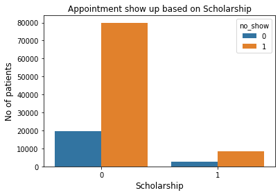

```python
# Plotting scholarship vs no show
feature_no_show_plot(df,"scholarship","Scholarship",12,False)
```

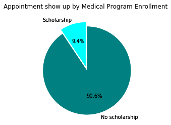

```python
scholarship_show_count = df.query('scholarship == 1 and no_show == 1').no_show.count()
no_scholarship_show_count = df.query('scholarship == 0 and no_show == 1').no_show.count()
total_show = df.query('no_show == 1').no_show.count()

scholarship_show_percentage = scholarship_no_show_count  / total_show * 100
no_scholarship_show_percentage = no_scholarship_show_count / total_show * 100

percent = [scholarship_show_percentage,no_scholarship_show_percentage]
values = ['Scholarship','No scholarship']

explode = [0,0.1]
colors = ['cyan','teal']
plt.pie(percent, explode = explode,colors=colors,labels=values, startangle=90, autopct='%1.1f%%')

feature_percentage_distribution_no_show(percent,values,colors,explode,"Medical Program Enrollment", 12)
```

#### Above chart, its clear Enrollment for health program has no impact on showing up for appoinments.

#### In fact patients with no health program benefit has shown up more.

### Appointment Week Days

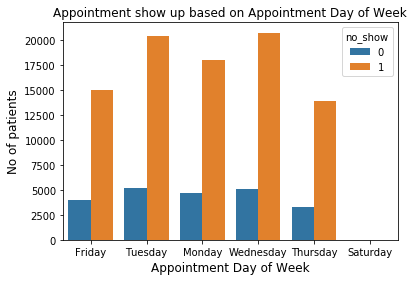

```python
# Plotting Appointment_week_day vs No show
weekdays = ['Monday','Tuesday','Wednesday','Thursday','Friday','Saturday']

feature_no_show_plot(df,"appointment_week_day","Appointment Day of Week",12,False)
```

```python
no_show_monday = df.query('appointment_week_day == "Monday" and no_show == 1').no_show.count()
no_show_tuesday = df.query('appointment_week_day == "Tuesday" and no_show == 1').no_show.count()
no_show_wednesday = df.query('appointment_week_day == "Wednesday" and no_show == 1').no_show.count()
no_show_thursday = df.query('appointment_week_day == "Thursday" and no_show == 1').no_show.count()
no_show_friday = df.query('appointment_week_day == "Friday" and no_show == 1').no_show.count()
no_show_saturday = df.query('appointment_week_day == "Saturday" and no_show == 1').no_show.count()
```

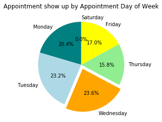

```python
percent = [monday_no_show_percentage,tuesday_no_show_percentage,wednesday_no_show_percentage,thursday_no_show_percentage,friday_no_show_percentage,saturday_no_show_percentage]
values = ['Monday','Tuesday','Wednesday','Thursday','Friday','Saturday']
colors = ['teal','lightblue','orange','lightgreen','yellow','lightseagreen']
explode = [0,0.0,0.1,0,0,0]

feature_percentage_distribution_no_show(percent,values,colors,explode,"Appointment Day of Week", 12)
```

### SMS Received

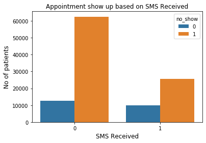

```python
# Plotting SMS Received vs No show
feature_no_show_plot(df,"sms_received","SMS Received",12,False)
```

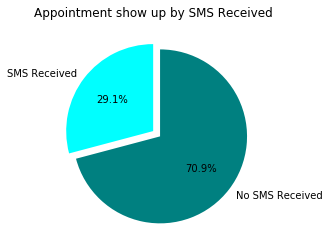

```python
sms_show_count = df.query('sms_received == 1 and no_show == 1').no_show.count()
no_sms_show_count = df.query('sms_received == 0 and no_show == 1').no_show.count()

total_show = df.query('no_show == 1').no_show.count()

sms_show_percentage = sms_show_count / total_show * 100
no_sms_show_percentage = no_sms_show_count / total_show * 100

percent = [sms_show_percentage,no_sms_show_percentage]
values = ['SMS Received','No SMS Received']

explode = [0,0.1]
colors = ['cyan','teal']

feature_percentage_distribution_no_show(percent,values,colors,explode,"SMS Received", 12)
```

### WaitDays

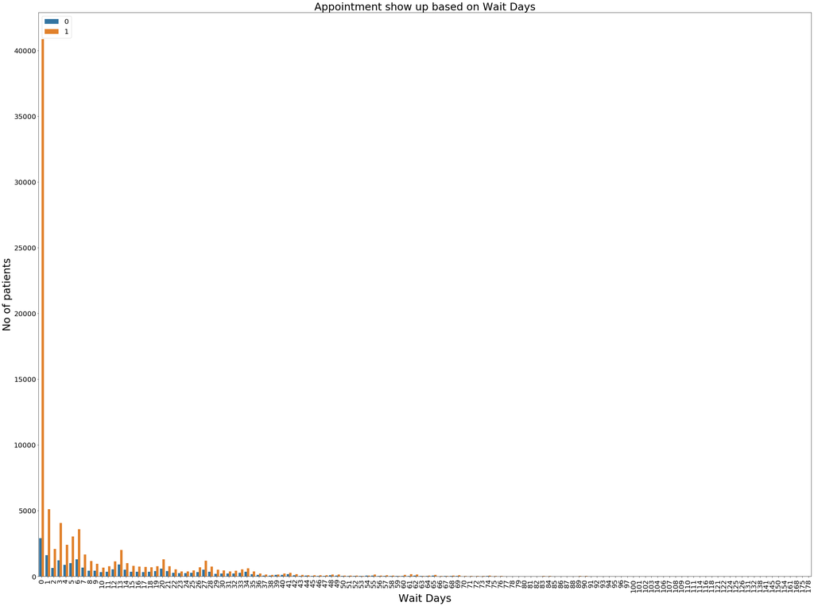

```python
# Plotting wait_days vs no show
fig = plt.figure(figsize=(40,30))

feature_no_show_plot(df,"wait_days","Wait Days",30,True)
```

#### Since there is large distribution of data, will be grouping the data.

```python
# Finding statistical data for wait_days
df.describe().wait_days
```

```
count    110526.000000
mean          9.532915
std          15.027724
min           0.000000
25%           0.000000
50%           3.000000
75%          14.000000
max         178.000000
Name: wait_days, dtype: float64
```

| Wait Category | Days |
| --- | --- |
| 0 | same day |
| 1-7 | week |
| 8-30 | month |
| 31-90 | quarter |
| 90-180 | >90 |

```python
# Categorizing wait days based on the above chart
bins = [-1, 0,7,30, 90, 180]
bin_names = ['same day', 'week','month','quarter','>90']

df['wait_category']= pd.cut(df.wait_days,bins,labels=bin_names)
df.head()
```

|  | patient_id | gender | scheduled_day | appointment_day | age | neighbourhood | scholarship | hipertension | diabetes | alcoholism | handcap | sms_received | no_show | appointment_week_day | wait_days | age_group | wait_category |
| --- | --- | --- | --- | --- | --- | --- | --- | --- | --- | --- | --- | --- | --- | --- | --- | --- | --- |
| 0 | 29872499824296 | F | 2016-04-29 18:38:08+00:00 | 2016-04-29 00:00:00+00:00 | 62 | JARDIM DA PENHA | 0 | 1 | 0 | 0 | 0 | 0 | 1 | Friday | 0 | 55-74 | same day |
| 1 | 558997776694438 | M | 2016-04-29 16:08:27+00:00 | 2016-04-29 00:00:00+00:00 | 56 | JARDIM DA PENHA | 0 | 0 | 0 | 0 | 0 | 0 | 1 | Friday | 0 | 55-74 | same day |
| 2 | 4262962299951 | F | 2016-04-29 16:19:04+00:00 | 2016-04-29 00:00:00+00:00 | 62 | MATA DA PRAIA | 0 | 0 | 0 | 0 | 0 | 0 | 1 | Friday | 0 | 55-74 | same day |
| 3 | 867951213174 | F | 2016-04-29 17:29:31+00:00 | 2016-04-29 00:00:00+00:00 | 8 | PONTAL DE CAMBURI | 0 | 0 | 0 | 0 | 0 | 0 | 1 | Friday | 0 | <18 | same day |
| 4 | 8841186448183 | F | 2016-04-29 16:07:23+00:00 | 2016-04-29 00:00:00+00:00 | 56 | JARDIM DA PENHA | 0 | 1 | 1 | 0 | 0 | 0 | 1 | Friday | 0 | 55-74 | same day |

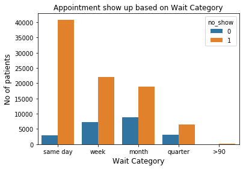

```python
# Plotting wait_category vs No show
feature_no_show_plot(df,"wait_category","Wait Category",12,False)
```

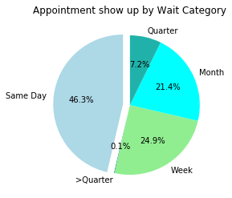

```python
same_day_show = df.query('wait_category == "same day" and no_show == 1').no_show.count()
week_show = df.query('wait_category == "week" and no_show == 1').no_show.count()
month_show = df.query('wait_category == "month" and no_show == 1').no_show.count()
quarter_show = df.query('wait_category == "quarter" and no_show == 1').no_show.count()
morethan_quarter_show = df.query('wait_category == ">90" and no_show == 1').no_show.count()

total_show = df.query('no_show ==1').no_show.count()

same_day_percentage = same_day_show  / total_show * 100
week_percentage = week_show  / total_show * 100
month_percentage = month_show  / total_show * 100
quarter_percentage = quarter_show  / total_show * 100
morethan_quarter_percentage = morethan_quarter_show  / total_show * 100

percent = [same_day_percentage,morethan_quarter_percentage, week_percentage, month_percentage, quarter_percentage ]
values = ['Same Day','>Quarter','Week','Month','Quarter']
colors = ['lightblue','teal','lightgreen','cyan','lightseagreen']
explode = [0.1,0,0,0,0]

feature_percentage_distribution_no_show(percent,values,colors,explode,"Wait Category", 12)
```

#### From the above chart, its clear that as wait time increase, there is a decrease in showing up for appointments.

## Conclusion

[output not shown]

### References

- Matplotlib - https://matplotlib.org/
- Pandas - https://pandas.pydata.org/pandas-docs/stable/
- Seaborn - https://seaborn.pydata.org/
- Data cleaning in Python - https://towardsdatascience.com/data-cleaning-with-python-and-pandas-detecting-missing-values-3e9c6ebcf78b
- Kaggle - Fundamental Data Analysis. https://www.kaggle.com/tigerli1997/fundamental-data-analysis.